# Mental health disabilities, stigma and access to accommodations.

# 1 Introduction

Mental health disabilities have emerged as the predominant disability group across post-secondary institutions in the United States. In fact, NPSAS data suggests that the significant increase in university enrollments from students with disabilities over the last two decades is largely driven by this disability group (2020 GAO data).

Despite this, prevalence estimates of this disability group vary widely across institutions over time:

- **University of California Undergraduate Experience Survey:**
  - *2025:* 30% of all students with disabilities reported a mental health disability, while 54% reported a learning disability.
  - *2022:* 39% of all disabilities were mental health, while only 4% reported a learning disability.
- **University of California, Berkeley (April 2025):** 2513/5680 (44%) of all students with disabilities reported a mental health disability, while learning disabilities comprised only 5%.
- **University of Texas, Austin (2024):** 2157/3885 (55.5%) of students with a disability reported a mental health disability, while learning disabilities comprised only 16%.
- **Syracuse University (2024):** Students may report more than one: 41% of all students with disabilities reported a mental health disability, while 74.1% reported a learning disability, which included ADHD (commonly categorized as a neurodevelopmental disability).
- **University of Oregon (2023):** 27.3% of students with disabilities reported a mental health disability, while 16% reported ADHD or a learning disability.

Some of this variation will be due to the different sociodemographics of the students who attend these very different institutions. Another significant contribution to the variability in prevalence estimates is due to the variability in the definition of what constitutes a mental health disability to researchers and university leadership, how disability service offices determine eligibility for disabilities, and the use of self-report data from students themselves. As we can see above, even within systems there exists variability, and across systems we see differences in how different diagnoses are categorized as disabilities. This can have a significant impact on the surveillance of students with mental health disabilities within the university system and can lead to severe misallocations of mental health and disability support services.[^1]

## 1.1 Service access

Compared to other disability groups, the rising prevalence of mental health disabilities has unique consequences for service provision within institutions whereby there is an increased demand for both mental health treatment through counselling and psychological services (CAPS) and disability management through disability service offices (DSO). In this context, it is estimated that a majority of students with mental health disabilities (SMHDs) do not receive accommodations, which may be a significant contributor to poorer mental health, social and academic outcomes for these students.

Felber et al., 2020 reported on 2016/2017 Healthy Minds data that 86.7% of SMHDs in their sample who qualified for a mental health disability under the ADA reported to not having registered for accommodations. Similarly, UC systems data from 2020 and 2022 indicated that 82% and 73% of students with mental health concerns/disorders did not receive accommodations, respectively [^2]. More recent data (Barnard-Brak 2022) has estimated that approximately 59% of students (n=3593) with psychological disorders were not registered for accommodations. [^3]. As with above, the lack of consistency in how psychological/mental health disabilities are classified makes inference on service underutilization difficult.

Ultimately, the common, persistent challenge with estimating the prevalence and service access underutilization for this cohort is the lack of data on functional limitations associated with student’s reporting mental health disorders. In other disability categories, functional limitations are central to how disabilities are classified and managed however, this is less discussed in research into mental health disabilities. This gap between mental health symptoms and functional limitations makes it difficult to infer on whether a reported mental health disorder ‘elevates’ to the level of disability, which impacts an institution’s ability to allocate resources based on the needs of its students. National surveys such as the BRFSS, NHANES and the NHIS all inquire about the functional limitations alongside specific diagnoses of chronic diseases and mental health disorders. As it is already an integral part how disability service offices assess students during accommodation interviews, collection of these data alongside mental health diagnoses can better triangulate the numbers and severity of students with mental health disorders who receive accommodations within universities.

## 1.2 Stigma

Understanding the role of disability stigma in service access for students with disabilities is critical considering it is well-established that there are differential service access rates dependent on sociocultural factors of students and the types of institutions they attend (Weis & Brittner, 2022). If students from disadvantaged gender, cultural or economic groups are more likely to experience stigma due to their disability then this will have a differential impact on how these groups access university services. This is a significant equity issue in research into service access for students with disabilities whereby early intervention into stigma may disproportionately improve access for those who need the most support. Despite this, there have been few investigations into the role of stigma, be it mental health or disability stigma, and service access for students with disabilities in post-secondary education.

Previous studies have described the important role that stigma plays in self-disclosure and service access for students with disabilities. Barnard-Brak et al., 2009 reported that students who did not accept their disability were less likely to request accommodations; Marshak et al., 2010 reported from qualitative data that disability stigma was a barrier for students with disabilities in accessing accommodations. For those with mental health “issues”, internalized/personal stigma was a barrier to seeking academic support and self-disclosure more broadly (Grimes 2020). For students with learning disabilities, nagative views of their disability and concerns about how other students, staff or faculty may respond to their disability negatively impacted their decision to self-disclose (Cole et al., 2015). Felber at al., 2020 explored differences in mental health treatment access between SMHDs who were and were not registered to DSOS, which showed small effect sizes for the negative association between perceived stigma and mental health treatment access. To this author’s knowledge, no study has quantiatively investigated the association between stigma and disability service access in students with psychological/mental health disabilities. Barnard-Brak et al., 2020 reported positive associations between receiving therapy or taking medication (for mental health reasons), and registering with DSOs, however stigma was not included in their model.

## 1.3 Study aims

This study aims to fill the gap in the service access and disability literature by exploring the association between stigma (personal and perceived) and service access (registering with DSOs or receiving mental health treatment) for students with psychological/mental health disabilities. Importantly, we build-on prior work by using a new Healthy Minds study self-reported disability group question (‘Do you have a disability, or disabilities, from any of the following categories?’), as opposed to the prior year’s question asking, ‘what disability a student received an accommodation for’, which constrained the entire sample of students with disabilities to those who received accommodations. Conversely, other analyses were limited by assuming that those with a diagnosed mental health disorder could be counted as those with a mental health disability, which is not necessarily true.

This analysis defines disability by combining self-identification of a disability with self-reported diagnosis of a mental health disorder, meaning our sample is unconstrained by registration with disability service office. This allows us to estimate prevalences and differences in accommodation access in relation to presence of stigma for students with psychological disabilities. Of note, our models incorporate mental health stigma rather than disability stigma (e.g., Post-Secondary Student Disability Stigma scale), which would be a novel testing of the relationship between mental health and disability management for this group [the only stigma measure available in the HMS dataset was the mental health stigma]. Few [perhaps no one?] have explored perceptions of students with mental health disorders and contextualizing their experiences within a conceptual model of disability.

This study first aims to explore **who** this population of students with disabilities are as defined by their symptom severity, functional limitations, the association between these two, and they’re difference compared to groups of students who report mental health diagnoses alone. We will define a population of this disability that is consistent with ADA definitions to elucidate a relationship between mental health disability and the role of stigma in mediating their access to support services. Our second aim is to explore the association between stigma and the probability of accessing mental health or disability services on campus. Ultimately, this study provides clarity on who this population of students with disabilities are, an estimate of their underutilization of support services, and the impact of mental health stigma on their access of support services.

# 2 Who are students with psychological/mental health disabilities?

This section explores the clinical characteristics of the population of students who may represent those with psychological/mental health disabilities. We investigate how students may or may not be identified as disabled based-upon a range of conditions and describe relationships with other disabilities.

## 2.1 Table 1 - Characterstics of weighted sample by disability type

We provide an overall demographic table adjusted using sampling weights provided, divided by disability type. Majority of the sample is female, white, and has a median age of 21.

| **Characteristic** | **Total**<sup>1</sup> | **None**, N = 120,641<sup>1</sup> | **Attention deficit/hyperactivity disorders**, N = 17,975<sup>1</sup> | **Deaf or hard of hearing**, N = 1,465<sup>1</sup> | **Learning disorders**, N = 3,132<sup>1</sup> | **Mobility impairments**, N = 654<sup>1</sup> | **Neurological disorders**, N = 1,617<sup>1</sup> | **Physical/health related disorders**, N = 5,080<sup>1</sup> | **Psychological disorder/condition**, N = 2,482<sup>1</sup> | **Visual impairments**, N = 8,069<sup>1</sup> | **Other (please specify)**, N = 14,123<sup>1</sup> | **Multiple disabilities**, N = 20,165<sup>1</sup> |
| --- | --- | --- | --- | --- | --- | --- | --- | --- | --- | --- | --- | --- |
| Age | 21 (8) | 21 (8) | 22 (7) | 22 (12) | 21 (8) | 27 (12) | 21 (8) | 21 (10) | 22 (9) | 20 (7) | 21 (8) | 22 (10) |
| Gender |  |  |  |  |  |  |  |  |  |  |  |  |
| Male | 80,602 (41%) | 49,949 (42%) | 8,179 (46%) | 711 (49%) | 1,060 (34%) | 318 (49%) | 621 (39%) | 1,480 (29%) | 569 (23%) | 3,660 (45%) | 6,591 (47%) | 7,465 (37%) |
| Female | 107,182 (55%) | 67,535 (56%) | 8,884 (50%) | 720 (49%) | 1,909 (61%) | 284 (43%) | 888 (55%) | 3,422 (68%) | 1,723 (70%) | 4,096 (51%) | 7,193 (51%) | 10,527 (52%) |
| Genderqueer | 1,560 (0.8%) | 513 (0.4%) | 217 (1.2%) | 3 (0.2%) | 33 (1.0%) | 2 (0.3%) | 37 (2.3%) | 40 (0.8%) | 27 (1.1%) | 50 (0.6%) | 49 (0.3%) | 591 (2.9%) |
| Non-binary | 1,886 (1.0%) | 726 (0.6%) | 264 (1.5%) | 2 (0.1%) | 22 (0.7%) | 7 (1.0%) | 27 (1.7%) | 47 (0.9%) | 53 (2.1%) | 70 (0.9%) | 58 (0.4%) | 611 (3.0%) |
| Transgender | 500 (0.3%) | 121 (0.1%) | 51 (0.3%) | 1 (<0.1%) | 35 (1.1%) | 25 (3.8%) | 4 (0.2%) | 11 (0.2%) | 14 (0.6%) | 28 (0.4%) | 26 (0.2%) | 185 (0.9%) |
| Prefer not to respond | 2,169 (1.1%) | 832 (0.7%) | 279 (1.6%) | 19 (1.3%) | 51 (1.6%) | 13 (2.0%) | 27 (1.7%) | 57 (1.1%) | 64 (2.6%) | 90 (1.1%) | 98 (0.7%) | 639 (3.2%) |
| Self-identified | 1,054 (0.5%) | 631 (0.5%) | 72 (0.4%) | 10 (0.7%) | 20 (0.6%) | 5 (0.8%) | 9 (0.5%) | 11 (0.2%) | 14 (0.6%) | 68 (0.8%) | 88 (0.6%) | 126 (0.6%) |
| Unknown | 449 | 334 | 30 | 0 | 1 | 0 | 4 | 12 | 18 | 7 | 20 | 21 |
| Race/Ethnicity |  |  |  |  |  |  |  |  |  |  |  |  |
| Black | 29,970 (15%) | 18,676 (16%) | 2,157 (12%) | 127 (8.6%) | 466 (15%) | 89 (14%) | 180 (11%) | 708 (14%) | 249 (10%) | 1,447 (18%) | 3,884 (28%) | 1,988 (9.9%) |
| AI/AN | 3,707 (1.9%) | 1,974 (1.6%) | 336 (1.9%) | 57 (3.9%) | 90 (2.9%) | 28 (4.3%) | 49 (3.0%) | 103 (2.0%) | 64 (2.6%) | 133 (1.7%) | 243 (1.7%) | 629 (3.1%) |
| Asian | 16,494 (8.5%) | 11,331 (9.5%) | 1,129 (6.3%) | 82 (5.6%) | 183 (5.8%) | 21 (3.3%) | 78 (4.8%) | 254 (5.0%) | 157 (6.3%) | 749 (9.3%) | 1,611 (11%) | 900 (4.5%) |
| Hispanic/Latinx | 24,495 (13%) | 15,892 (13%) | 1,844 (10%) | 176 (12%) | 361 (12%) | 51 (7.8%) | 125 (7.7%) | 428 (8.4%) | 271 (11%) | 1,144 (14%) | 2,361 (17%) | 1,842 (9.2%) |
| NH/PI | 570 (0.3%) | 361 (0.3%) | 40 (0.2%) | 9 (0.6%) | 6 (0.2%) | 3 (0.5%) | 1 (<0.1%) | 23 (0.5%) | 3 (0.1%) | 28 (0.3%) | 36 (0.3%) | 58 (0.3%) |
| Middle Eastern | 2,504 (1.3%) | 1,552 (1.3%) | 384 (2.1%) | 9 (0.6%) | 22 (0.7%) | 13 (2.0%) | 12 (0.7%) | 66 (1.3%) | 27 (1.1%) | 67 (0.8%) | 179 (1.3%) | 172 (0.9%) |
| White | 114,599 (59%) | 68,862 (58%) | 11,945 (67%) | 984 (67%) | 1,959 (63%) | 432 (66%) | 1,167 (72%) | 3,448 (68%) | 1,662 (67%) | 4,387 (55%) | 5,529 (39%) | 14,225 (71%) |
| Self-identified | 1,993 (1.0%) | 1,091 (0.9%) | 121 (0.7%) | 20 (1.4%) | 39 (1.2%) | 16 (2.4%) | 6 (0.4%) | 34 (0.7%) | 44 (1.8%) | 92 (1.1%) | 244 (1.7%) | 286 (1.4%) |
| Unknown | 1,072 | 901 | 20 | 1 | 6 | 0 | 0 | 16 | 5 | 23 | 36 | 64 |
| PHQ-9 score | 8 (6) | 7 (6) | 9 (6) | 7 (6) | 8 (6) | 9 (6) | 9 (6) | 9 (6) | 11 (7) | 7 (6) | 6 (6) | 12 (7) |
| Unknown | 18,572 | 16,601 | 462 | 29 | 84 | 21 | 39 | 140 | 74 | 191 | 510 | 422 |
| GAD-7 score | 7 (6) | 6 (6) | 8 (6) | 6 (6) | 7 (6) | 7 (6) | 8 (6) | 8 (6) | 11 (6) | 6 (6) | 5 (6) | 10 (6) |
| Unknown | 18,696 | 17,236 | 289 | 39 | 63 | 6 | 35 | 69 | 36 | 211 | 411 | 302 |

<sup>1</sup> Median (SD); n (%)

## 2.2 Students who self-identify as having a psychological disability

In this dataset, mental health disability is represented by a variable called disab_1_7 that is one of a list of 9 disability types that students can select if it applies to them. We will be using the term psychological disability and mental health disability interchangeably within this paper.

Respondents are asked: Do you have a disability, or disabilities, from any of the following categories? (Select all that apply): Psychological disorder/condition.

I will use this section to explore the prevalence of these students and their uniqueness compared to other groups; I will present a few datapoints to explore these students within this dataset.  
**Psychological disability overview:**

- 92.4% of students who report a psychological disability also report a depressive or anxiety disorder.
- 38% of students who report a psychological disability also report ADHD.
- 36.9% of students who report a psychological disability receive accommodations (note: this may be for a co-occurring disability such as ADHD or vision impairment).
- 69.3% of students who report a psychological disability also report another type of disability.

## 2.3 Psychological disability and disability services

In order to get a better appreciation of how mental health/psychological disability may be impacting disability service access, it is important to remove potential counfounding from other disability groups. Using the ‘psychological disability’ variable as is will also include students who have selected other disabilities, which may mean the mental health disability arose secondarily to a ‘primary’ disability, which is common in this population. In our case, it is useful to constrain our dataset to those who ONLY report a mental health disability absent of another. Further, we consider ‘registering with disability service office’ as a proxy for accessing academic accommodations (I cannot think of a situation where a student would be registered with accommodations but not have at least been granted acommodations… whether they received them is different).

I perform two steps: 1) I construct a dataframe restricted to those who ONLY reported psychological disabilities; 2) Perform quality control by removing those who did not also report a mental health diagnosis from a professional (that would exclude them from having a possible psychological/mental health disability). This accounted for ~5% of the subsample.  
**Percentage of students who report only psychological disability and have a mental health disorder diagnosis:**

- 94.9% of students who report only a psychological disability also report a mental health diagnosis.

**Percentage of students who report only psychological disability and have a mental health disorder diagnosis who are registered with their disability service office:**

- 27.8% of these students receive accommodations.

## 2.4 Mental health outcomes between mental health diagnosed population and those with psychological disabilities

It is also important to explore how students who only identify as having a psychological/mental health disability with a mental health diagnosis differ from the general population of those that report mental health diagnosis without a psychological/mental health disability.

I will use two mental health outcomes measures to explore this: the PHQ9 and the GAD7.

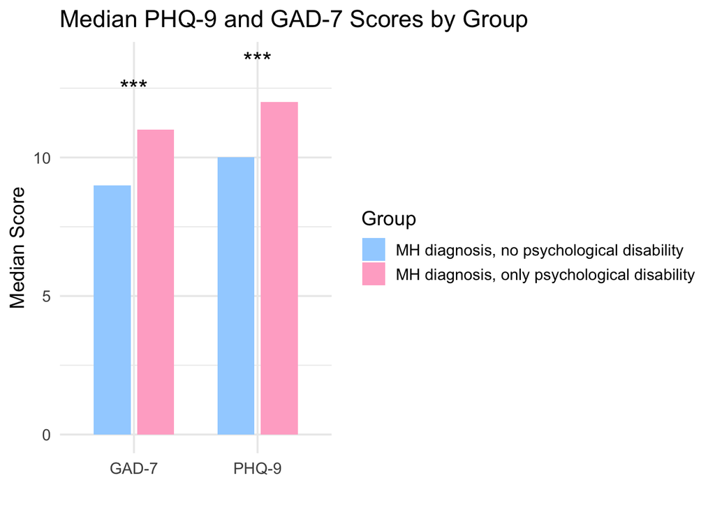

**This makes sense:** a big difference between those with a MH disorder and those with only a psychological/mental health disability is the severity of symptoms i.e., those with psychological disabilities describe more severe mental health symptoms than those who report a mental health diagnosis without a psychological disability.

This leads us to consider the association between the severity of symptoms and disability, which should be connected mechanistically by the impact symptom severity has on *functional limitations*. Recent NHANES data demonstrated exactly this (Meshkate et al., 2025): a strong positive association between depressive symptoms as measured by the PHQ9 and functional limitations as measured by the Disability Questionnaire (measures based on activities of daily living).

## 2.5 Functional limitations and disability

In this context, those reporting severe symptoms from a mental health diagnosis are likely to also report functional limitations, which would qualify them as having a disability. We can first explore this within our own data using bespoke functional limitations equivalent measures included in our dataset (dep_imp & gad7_impa), which asks: “How difficult have these problems (noted above) made it for you to do your work, take care of things at home, or get along with other people?” This prompts a 4-point Likert scale response from Not at all difficult –> Extremely difficult.

**Table 2: Proportion of students with diagnosed MH disorder and severe symptoms**

| Functional Limitation | Proportion |
| --- | --- |
| No | 0.256 |
| Yes | 0.744 |

**Table 3: Proportion of students who report a psychological disability who report a functional limitation**

| Functional Limitation | Psychological Disability | Proportion |
| --- | --- | --- |
| Yes | Yes | 0.137 |
| Yes | No | 0.607 |
| No | Yes | 0.028 |
| No | No | 0.228 |

**Table 4: Proportion of students with a mental health diagnosis and functional limitations who report a psychological disability**

| Psychological disability | Proportion |
| --- | --- |
| Yes | 0.184 |
| No | 0.816 |

### 2.5.2 Proportion of students with that report functional limitations who self-identify as having psychological disability

82% of those with a MH diagnosis who reported functional limitations (due to severe depressive or anxiety symptoms) do NOT report having a psychological disability (Table 4). This represents a significant proportion of this sample who would be considered having a psychological/mental health disability but do not self-identify as having one.

One caveat is that of these students, 60% identify a non-psychological disability and so may consider the functional limitations they experience due to depression/anxiety a result of their ‘primary’ disability, not a psychological disability. Despite this, a significant number of students with non-psychological disabilities DO co-report a psychological/mental health disability in the presence of functional limitations related to depression/anxiety, so it is unlikely entirely explained by this. [^4]

Regardless, **40% of those with functional limitations from their MH diagnosis who do not report ANY other disability, also do not report a psychological disability**. This leads us to our most conservative estimate that 4/10 students who report functional limitations due to severe mental health symptoms who are also not receiving disability care for a non-psychological disability do not self-identify as having a psychological disability despite their eligibility. This is about 4% of the entire sample!

Importantly, a majority of this group also reports having receive mental health treatment in prior 12 months, indicating a potential role for mental health providers to support this self-identification. This may mean that clinicians/mental health providers should increasingly include functional limitations within their assessments and use this to further educate students on the link between functional limitations and disability.

### 2.5.3 Interpretation

This access gap may be a result of unmeasured disability stigma in this group where students may recognize their mental health disorder as disabling however, feel uncomfortable referring to it as a psychological disability. It may also be a result of a lack of disability cultural competency where these students do not recognize that their mental health disorder, which is causing significant limitations in their daily activities (such as socializing or studying, attending class etc) is disabling and thus, they have a disability.

It may also relate to the use of the term psychological instead of mental health: students may be not understand that depressive or anxiety disorders are a psychological disorder/condition since mental health is the most common parlance for these terms currently. This speaks to the importance of language in the assessment, communication and delivery of disability care for these students, particularly those across different sociocultural and linguistic backgrounds.

An important caveat to these data regarding unmet care needs is that respondents are required self-identify as having a disability before they can select whether they are registered with a disability service office (proxy for receiving accommodations). It is possible that there is a cohort within this sample who reported severe depressive or anxiety symptoms that caused functional limitations, who do NOT report having a psychological disability but DO receive accommodations. This would mean that they are having their disability care needs met despite not reporting a psychological disability (possibly for a different disability) and thus are not counted here as receiving accommodations.

# 3 Disability self-identification, stigma and functional limitations

So, now that we understand the extent that:

1. Severe MH symptoms relate to functional limitations in this population of students with mental health diagnoses.
2. A report of functional limitations due to their severe MH symptoms alone is unlikely to mean that a student identifies as having a psychological disability i.e., severity of symptoms does not predict self-identification.

**This begs the question:** what might the mechanism be by which a student with mental health diagnoses ‘chooses’ to self-identify as having a psychological disability or not? This is critical a question considering that in order to access accommodations through disability services students must self-disclose their disability, which requires a student to first self-identify as *having* a psychological/mental health disability.

A priori evidence suggests that stigma is an important factor here. I will run two regression with the exposure variable of stigma (personal then perceived) to explore how this impacts the probability of a student with a mental health diagnoses and severe dep/anx symptoms self-identifying as having a psychological disability.

For our analyses, we only have access to mental health stigma (personal, perceived and stigma of seeking mental health treatment), not disability stigma. For students with psychological/mental health disabilities, it is likely that mental health stigma interacts with disability stigma in ways that it does not for other disability groups; in this context, would mental health stigma and disability stigma be measuring different constructs? It is possible the answer to this question is yes however, I believe there would be a strong correlation between the two.

Finally, we adjust our regression model by age, race/ethnicity, gender, and symptom severity through summary scores of PHQ9 and GAD7, and functional limitations, as confounders of the association between mental health stigma and self-identification of a psychological disability.

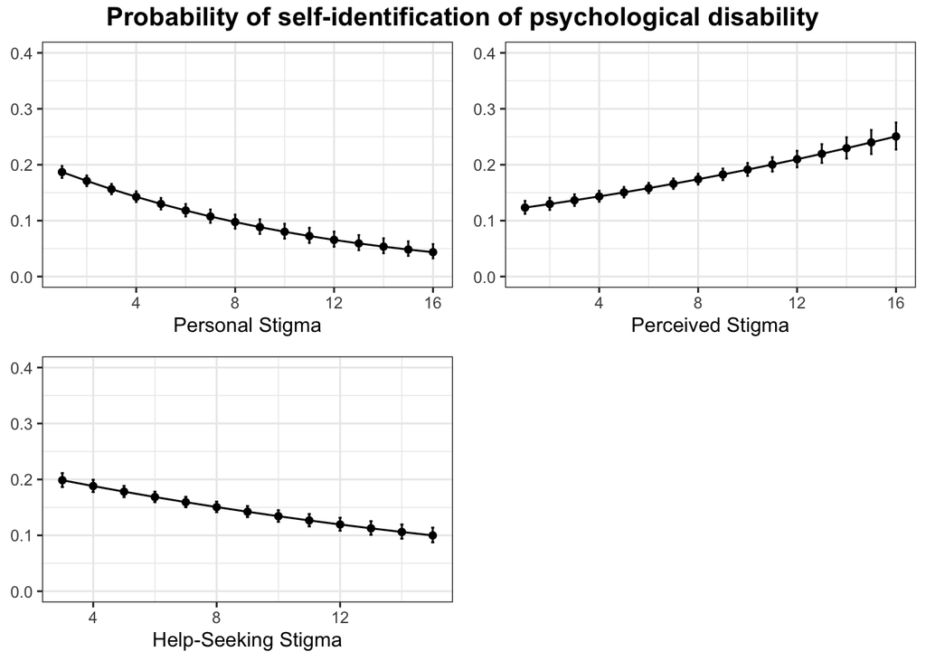

Perceived mental health stigma described the opposite association: higher perceived mental health stigma resulted in higher probability of self-identifying with a psychological disability. I do not know why this would be!

These data are are critical as self-identification is a pre-requisite to accessing disability care in post-secondary education e.g., students need to self-disclose their disability to receive accommodations from disability service offices. If stigma is preventing self-disclosure of a disability, ipso facto stigma is preventing access to disability care. For those who do not report a functional limitation this may not be significant as they, according to the accepted ADA definition of disability, would not be eligible for disability care. However, for those who do report functional limitations, this is very important!

# 4 Stigma, and access to disability and mental health services

We have established an association between stigma and self-identification of psychological disability however, does stigma also impact a student who has *already* self-identified and their subsequent self-DISCLOSURE to disability or mental health services?

In these models, we constrain our sample to **students who ONLY reported a psychological disability** to avoid biasing our sample with those who may have received care for a co-occuring disability. We also condition our sample on those who report a mental health diagnosis as a quality control. We also adjust our regression models on age, race/ethnicity, gender, parental education, functional limitation (severity) as confounders of the association between mental health stigma and both service access outcomes.

Finally, there are modest missing data for stigma values, so we perform multiple imputations (MICE) to impute data across our variables of interest. Models would not converge with so much missing data so this was a necessary step. While this seems serious, this is just because we are treating our stigma sum scores as linear variables, and at the extreme ends there are few responses for pairwise comparisons in our regression models, particularly as we crosstab.

## 4.1 All students with psychological disabilities

Our first models will explore these associations over our total sample. Predicted probabilities will use ‘modal’ averages from our sample to demonstrate the effect of stigma on our two outcomes: registered with DSOs & mental health treatment in the previous 12 months.

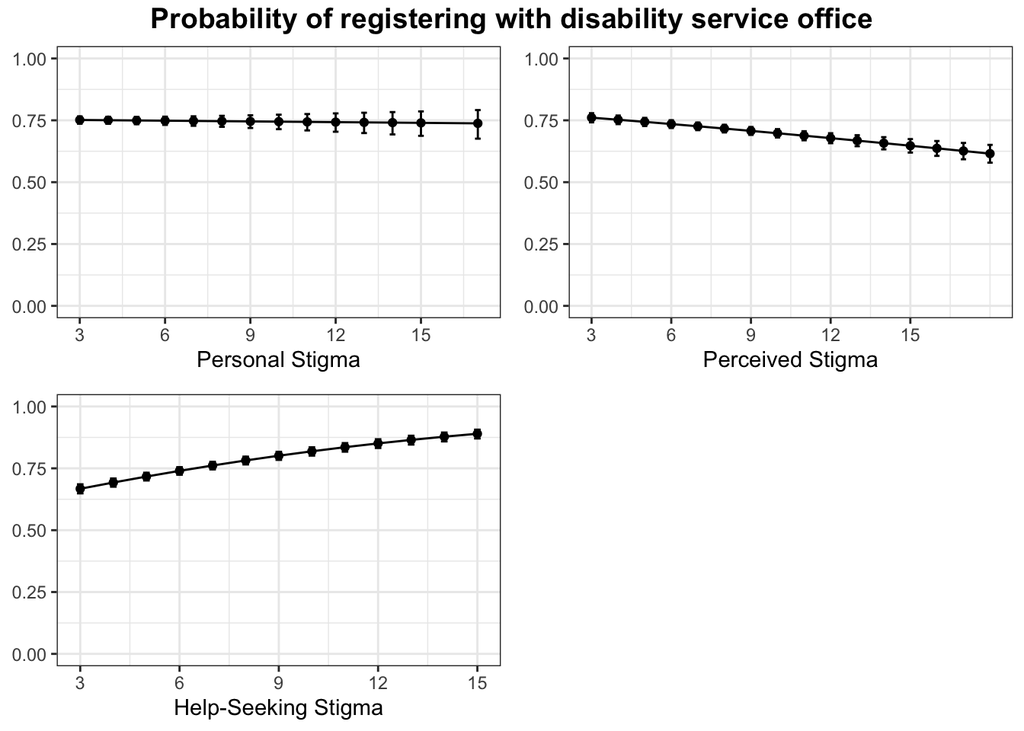

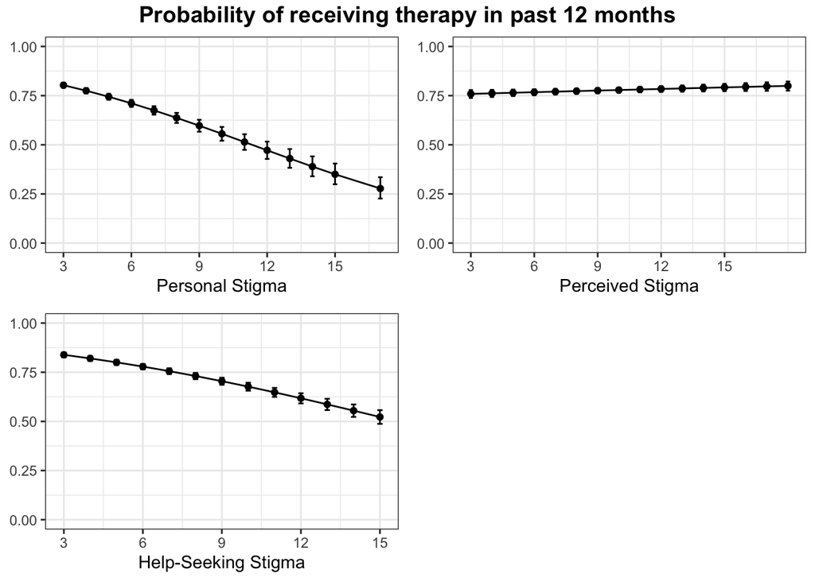

Our model estimates that personal mental health stigma is not associated with registering with disability service offices. Perceived mental health stigma described a small negative association with registering with disability service offices. Interestingly, mental health help-seeking stigma *is* positively associated with registering with disability service offices, and negatively associated with receiving mental health therapy over the last 12 months. This will be a consistent finding across all sub-group analyses too! [^5]

Intuitively, personal mental health stigma is negatively associated with receiving mental health treatment in the prior 12 months and perceived stigma showed no association.

### 4.1.1 Interpretation of total sample results

These are the data where we have the most confidence due to large sample sizes. Overall, it seems that once students have self-identified, personal and perceived stigma no longer have a significant impact on their access disability services (while perceived stigma showed minor significance, the effect was small). This places greater emphasis on the need to support students with mental health diagnoses who report functional limitations due to severe symptoms but have not yet made the connection with disability to self-identify. This evidence suggests that once they have self-identified, these stigmas are not a barrier to service access.

Most interesting is help-seeking stigma and its opposite relationship with mental health treatment and disability service access. It is possible that for students who self-identify with a psychological disability (as is the case in this sample) they have already overcome the disability stigma aspect to their mental health disorder however, mental health stigma remains the significant barrier. It is unclear how the underlying constructs of disability and mental health stigma would differ for these students but it may be that in this case receiving accommodations instead of mental health treatment is preferable for those with high mental health stigma. One caveat is that these students have engaged with a mental health provider at some point in their lives previously, as they report a diagnosis for a mental health condition. It may be that prior experience engendered a degree of mental health stigma or the lack of recent mental health treatment drives increased mental health stigma (reverse causality).

Regardless, this elevates the role of disability service staff in mental health treatment for these students as they may be the first exposure this cohort has with university support services. Where mental health providers may play a role in supporting students with pyschological disorders and functional limitations to self-identify as having a disability, the inverse role may be important for disability specialists in DSOs. These staff emphasizing that accommodations are not mental health treatment while optimizing referral processes between DSOs and mental health services for these students could prevent the underutilization of these services for this group.

## 4.2 Effect modification by gender

Does stigma’s association with accessing disability services or mental health treatment depend on gender?

Our sample size is limited and therefore, we limit our visualizations to gender groups with sufficient numbers to make reasonable inferences (only male and female).

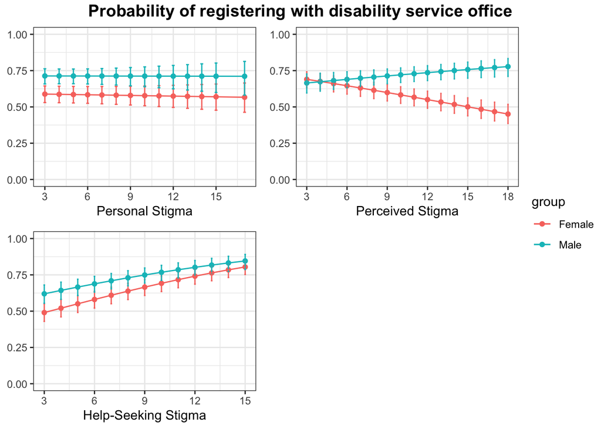

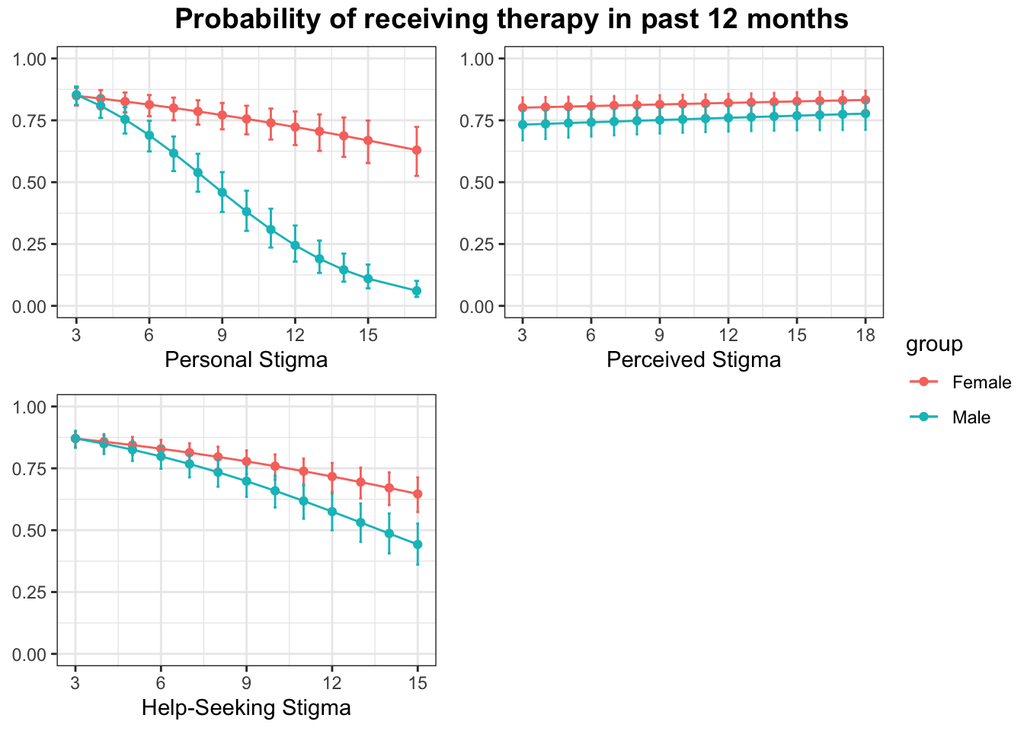

### 4.2.1 Interpretation of gender interaction results

It is well-understood that there is a gender effect to accessing mental health care, which spans age groups, cultures and systems of care. Here we replicate these findings in a sample of students with reported psychological disabilities, and describing a large differential effect of personal stigma to receiving mental health treatment in the prior year (about a 60% difference at the highest personal stigma value).

## 4.3 Effect modification by parental education

Does stigma’s association with accessing disability services or mental health treatment depend on parental education?

Here we draw on the relationship between parental education and socioeconomic status, which is not directly measured in this dataset. While this association is not perfectly correlated, parental education is a **strong** predictor of socioeconomic status in the US, and we theorize that there will also be an independent effect of parental education on service access through cultural competency/knowledge of service by students who’s parents have previously attended a college or university.

Similar to prior plots, we have categorized parental education into four levels, and dropped those who responded ‘Don’t know’ from our visualizations.

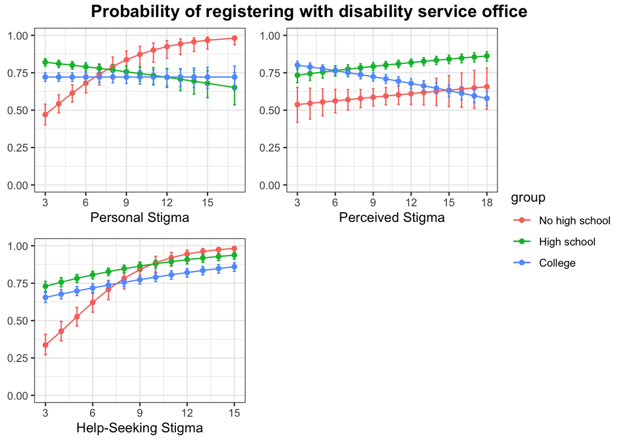

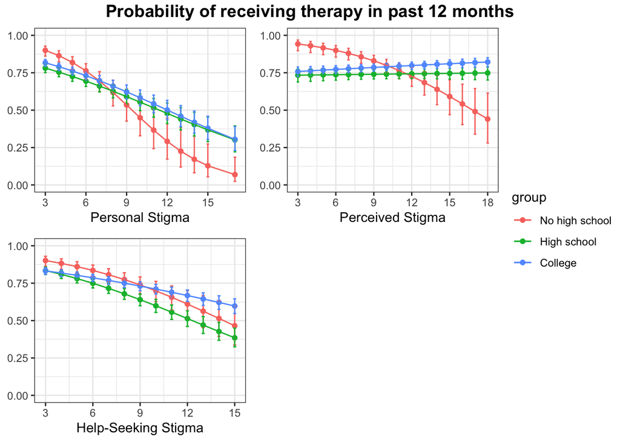

At the lowest stigma values for all three measures, students who reported that neither parent had a high school degree were the least likely to register with the disability service office. The positive interaction effects for this group also described that increasing personal and help-seeking stigma had a greater positive association with registering compared to other groups (at least one parent that went to High school or College).

### 4.3.1 Interpretation of parental education interaction results

At the lowest mental health stigma values, students who neither parent attained a high school diploma were the least likely to register with DSOs, which persisted until the median stigma values for personal and help-seeking stigma where they became the most likely. Further, this group was also the most likely to have received therapy in the previous year at the lowest stigma values. Similar to males, this differential effect of stigma between these two support services for students who neither parent attained a high school diploma is interesting. It may be that to this particular ‘disadvantaged’ group, students with the highest mental health stigma may avoid mental health treatment opting for accommodations instead. This may be a result of a previous bad experience with mental health treatment as reported in the general results interpretation, but may also be a case of reverse causality.

# 5 References

Stigma measures: Eisenberg et al., 2009 (https://websites.umich.edu/~daneis/papers/hmpapers/Stigma%20_Eisenberg%20et%20al%202009_.pdf)

[^1]: For the purpose of this study, we adhere to the ADA definition of psychiatric (mental health/psychological) disabilities as: “a mental impairment that substantially limits one or more of the major life activities of [an] individual; a record of impairment; or being regarded as having such an impairment.”
[^2]: One limitation with the Felber study and UC data is the claim that participants who reported that they had been diagnosed with a mental health disorder by a health professional were thus qualified under the ADA for a mental health disability. A mental health disorder diagnosis does not automatically qualify as a disability without evidence of functional limitation; a proportion of the students included in this group would not report functional limitations due to their disability. This figure of 86.7% is very likely an underestimation of the proportion of SMHDs who registered for accommodations by including students who are unlikely to meet the criteria of disability. As we will argue later, it is much more useful to constrain this sample to those disagnosed with a mental health disorder who also report SEVERE symptoms, which is strongly correlated with functional limitations.
[^3]: Reductions in the percentage of these students serviced by DSOs from 2016 to 2024 may be a result of a reduction in the availability of services (staff to student ratios increasing), an increase in barriers to *accessing* these services (stigma, infrastructural, perceived need), or that the increased percentage of students reporting mental health disorders are presenting with ‘milder’ symptoms/fewer functional limitations (no evidence to suggest this). Importantly, the denominator in this proportion has increased faster than the numerator (i.e., more students are receiving disability care but even more students are reporting psychological/mental health disabilities)
[^4]: This does however, beg the question: is a mental health disorder/condition, which arises due to another disability (ADHD, dyslexia, specific learning disability) that students report as leading to functional limitations simply a symptom of their original disability, or is it its own disability? If the latter, how does this impact care? Perhaps disability care focuses on managing the functional limitations associated with the original disability (which MAY be different to the psychological disability) with the intention that downstream it will benefit the psychological/mental health disability. Perhaps disability care providers consider the management of the mental health disorders that arise from another disability within the purview of mental health providers/clinicians. There remains a lack of clarity on the management of ‘secondary’ psychological/mental health disabilities from this perspective.
[^5]: May seem obvious but worth discussing the difference between personal stigma and help-seeking stigma here as they appear quite similar at the question-level: personal seems to assess a respondent’s stigma towards the idea of mental health while help-seeking assesses stigma towards seeking help for a mental health problem